[figure not shown]

# Exploratory Data Analysis of COVID-19 World Vaccination Progress

[figure not shown]

# Welcome!

### Introduction to the dataset:

**This dataset contains the information on COVID-19 vaccination details that were collected across different countries around the world. This dataset is an open source data and is taken from the most popular website, kaggle. Since it is an open source data, anyone like me can access it for analysis purposes. Some of the information that can be seen in the dataset are:**

1. **Country**- this is the country for which the vaccination information is provided;
2. **Country ISO Code** - ISO code for the country;
3. **Date** - date for the data entry; for some of the dates we have only the daily vaccinations, for others, only the (cumulative) total;
4. **Total number of vaccinations** - this is the absolute number of total immunizations in the country;
5. **Total number of people vaccinated** - a person, depending on the immunization scheme, will receive one or more (typically 2) vaccines; at a certain moment, the number of vaccination might be larger than the number of people;
6. **Total number of people fully vaccinated** - this is the number of people that received the entire set of immunization according to the immunization scheme (typically 2); at a certain moment in time, there might be a certain number of people that received one vaccine and another number (smaller) of people that received all vaccines in the scheme;
7. **Daily vaccinations (raw)** - for a certain data entry, the number of vaccination for that date/country;
8. **Daily vaccinations** - for a certain data entry, the number of vaccination for that date/country;
9. **Total vaccinations per hundred** - ratio (in percent) between vaccination number and total population up to the date in the country;
10. **Total number of people vaccinated per hundred** - ratio (in percent) between population immunized and total population up to the date in the country;
11. **Total number of people fully vaccinated per hundred** - ratio (in percent) between population fully immunized and total population up to the date in the country;
12. **Number of vaccinations per day** - number of daily vaccination for that day and country;
13. **Daily vaccinations per million** - ratio (in ppm) between vaccination number and total population for the current date in the country;
14. **Vaccines used in the country** - total number of vaccines used in the country (up to date);  
    **The Source of Data:** The data was collected from **`Kaggle`** website. Link: https://www.kaggle.com/gpreda/covid-world-vaccination-progress/

### How to run the code

This is an executable [*Jupyter notebook*](https://jupyter.org) hosted on [Jovian.ml](https://www.jovian.ml), a platform for sharing data science projects. You can run and experiment with the code in a couple of ways: *using free online resources* (recommended) or *on your own computer*.

#### Option 1: Running using free online resources (1-click, recommended)

The easiest way to start executing this notebook is to click the "Run" button at the top of this page, and select "Run on Binder". This will run the notebook on mybinder.org, a free online service for running Jupyter notebooks. You can also select "Run on Colab" or "Run on Kaggle".

#### Option 2: Running on your computer locally

1. Install Conda by [following these instructions](https://conda.io/projects/conda/en/latest/user-guide/install/index.html). Add Conda binaries to your system `PATH`, so you can use the `conda` command on your terminal.
2. Create a Conda environment and install the required libraries by running these commands on the terminal:

```
conda create -n zerotopandas -y python=3.8
conda activate zerotopandas
pip install jovian jupyter numpy pandas matplotlib seaborn opendatasets --upgrade
```

1. Press the "Clone" button above to copy the command for downloading the notebook, and run it on the terminal. This will create a new directory and download the notebook. The command will look something like this:

```
jovian clone notebook-owner/notebook-id
```

1. Enter the newly created directory using `cd directory-name` and start the Jupyter notebook.

```
jupyter notebook
```

You can now access Jupyter's web interface by clicking the link that shows up on the terminal or by visiting http://localhost:8888 on your browser. Click on the notebook file (it has a `.ipynb` extension) to open it.

## Step: 1 Downloading and Extracting the Dataset

We start the analysis process by first downloading the dataset from Kaggle. I have saved the dataset to my working dicterory mannually and had extracted the dataset to the jupyter notebook by using pandas library function

```python
!pip install jovian opendatasets --upgrade --quiet
```

```python
import os
import pandas as pd
os.getcwd()
pd.read_csv('country_vaccinations.csv')
```

|  | country | iso_code | date | total_vaccinations | people_vaccinated | people_fully_vaccinated | daily_vaccinations_raw | daily_vaccinations | total_vaccinations_per_hundred | people_vaccinated_per_hundred | people_fully_vaccinated_per_hundred | daily_vaccinations_per_million | vaccines | source_name | source_website |
| --- | --- | --- | --- | --- | --- | --- | --- | --- | --- | --- | --- | --- | --- | --- | --- |
| 0 | Afghanistan | AFG | 2021-02-22 | 0.0 | 0.0 | NaN | NaN | NaN | 0.00 | 0.00 | NaN | NaN | Oxford/AstraZeneca, Pfizer/BioNTech, Sinopharm... | World Health Organization | https://covid19.who.int/ |
| 1 | Afghanistan | AFG | 2021-02-23 | NaN | NaN | NaN | NaN | 1367.0 | NaN | NaN | NaN | 35.0 | Oxford/AstraZeneca, Pfizer/BioNTech, Sinopharm... | World Health Organization | https://covid19.who.int/ |
| 2 | Afghanistan | AFG | 2021-02-24 | NaN | NaN | NaN | NaN | 1367.0 | NaN | NaN | NaN | 35.0 | Oxford/AstraZeneca, Pfizer/BioNTech, Sinopharm... | World Health Organization | https://covid19.who.int/ |
| 3 | Afghanistan | AFG | 2021-02-25 | NaN | NaN | NaN | NaN | 1367.0 | NaN | NaN | NaN | 35.0 | Oxford/AstraZeneca, Pfizer/BioNTech, Sinopharm... | World Health Organization | https://covid19.who.int/ |
| 4 | Afghanistan | AFG | 2021-02-26 | NaN | NaN | NaN | NaN | 1367.0 | NaN | NaN | NaN | 35.0 | Oxford/AstraZeneca, Pfizer/BioNTech, Sinopharm... | World Health Organization | https://covid19.who.int/ |
| ... | ... | ... | ... | ... | ... | ... | ... | ... | ... | ... | ... | ... | ... | ... | ... |
| 17602 | Zimbabwe | ZWE | 2021-05-08 | 657838.0 | 509274.0 | 148564.0 | 17076.0 | 19648.0 | 4.43 | 3.43 | 1.00 | 1322.0 | Sinopharm/Beijing | Ministry of Health | https://twitter.com/MoHCCZim/status/1392575941... |
| 17603 | Zimbabwe | ZWE | 2021-05-09 | 684243.0 | 526066.0 | 158177.0 | 26405.0 | 22863.0 | 4.60 | 3.54 | 1.06 | 1538.0 | Sinopharm/Beijing | Ministry of Health | https://twitter.com/MoHCCZim/status/1392575941... |
| 17604 | Zimbabwe | ZWE | 2021-05-10 | 690653.0 | 529360.0 | 161293.0 | 6410.0 | 21877.0 | 4.65 | 3.56 | 1.09 | 1472.0 | Sinopharm/Beijing | Ministry of Health | https://twitter.com/MoHCCZim/status/1392575941... |
| 17605 | Zimbabwe | ZWE | 2021-05-11 | 709772.0 | 539526.0 | 170246.0 | 19119.0 | 21428.0 | 4.78 | 3.63 | 1.15 | 1442.0 | Sinopharm/Beijing | Ministry of Health | https://twitter.com/MoHCCZim/status/1392575941... |
| 17606 | Zimbabwe | ZWE | 2021-05-12 | 730365.0 | 549797.0 | 180568.0 | 20593.0 | 22019.0 | 4.91 | 3.70 | 1.21 | 1481.0 | Sinopharm/Beijing | Ministry of Health | https://twitter.com/MoHCCZim/status/1392575941... |

17607 rows × 15 columns

The dataset has been downloaded and extracted.

Let us save and upload our work to Jovian before continuing.

```python
project_name = "COVID-19 World Vacination Progress Analysis"
```

```python
!pip install jovian --upgrade -q
```

```python
import jovian
```

```python
jovian.commit(project=project_name)
```

```
[jovian] Attempting to save notebook..
[jovian] Updating notebook "kiranprasanth01/covid-19-world-vacination-progress-analysis" on https://jovian.ai/
[jovian] Uploading notebook..
[jovian] Capturing environment..
[jovian] Committed successfully! https://jovian.ai/kiranprasanth01/covid-19-world-vacination-progress-analysis
```

```
'https://jovian.ai/kiranprasanth01/covid-19-world-vacination-progress-analysis'
```

## Step: 2 Data Preparation and Cleaning

Here we do the process of dealing with missing data and filling it with appropriate values. Also understanding the dataset and its contents present in rows and columns

```python
dataset_df = pd.read_csv('country_vaccinations.csv')
dataset_df
```

|  | country | iso_code | date | total_vaccinations | people_vaccinated | people_fully_vaccinated | daily_vaccinations_raw | daily_vaccinations | total_vaccinations_per_hundred | people_vaccinated_per_hundred | people_fully_vaccinated_per_hundred | daily_vaccinations_per_million | vaccines | source_name | source_website |
| --- | --- | --- | --- | --- | --- | --- | --- | --- | --- | --- | --- | --- | --- | --- | --- |
| 0 | Afghanistan | AFG | 2021-02-22 | 0.0 | 0.0 | NaN | NaN | NaN | 0.00 | 0.00 | NaN | NaN | Oxford/AstraZeneca, Pfizer/BioNTech, Sinopharm... | World Health Organization | https://covid19.who.int/ |
| 1 | Afghanistan | AFG | 2021-02-23 | NaN | NaN | NaN | NaN | 1367.0 | NaN | NaN | NaN | 35.0 | Oxford/AstraZeneca, Pfizer/BioNTech, Sinopharm... | World Health Organization | https://covid19.who.int/ |
| 2 | Afghanistan | AFG | 2021-02-24 | NaN | NaN | NaN | NaN | 1367.0 | NaN | NaN | NaN | 35.0 | Oxford/AstraZeneca, Pfizer/BioNTech, Sinopharm... | World Health Organization | https://covid19.who.int/ |
| 3 | Afghanistan | AFG | 2021-02-25 | NaN | NaN | NaN | NaN | 1367.0 | NaN | NaN | NaN | 35.0 | Oxford/AstraZeneca, Pfizer/BioNTech, Sinopharm... | World Health Organization | https://covid19.who.int/ |
| 4 | Afghanistan | AFG | 2021-02-26 | NaN | NaN | NaN | NaN | 1367.0 | NaN | NaN | NaN | 35.0 | Oxford/AstraZeneca, Pfizer/BioNTech, Sinopharm... | World Health Organization | https://covid19.who.int/ |
| ... | ... | ... | ... | ... | ... | ... | ... | ... | ... | ... | ... | ... | ... | ... | ... |
| 17602 | Zimbabwe | ZWE | 2021-05-08 | 657838.0 | 509274.0 | 148564.0 | 17076.0 | 19648.0 | 4.43 | 3.43 | 1.00 | 1322.0 | Sinopharm/Beijing | Ministry of Health | https://twitter.com/MoHCCZim/status/1392575941... |
| 17603 | Zimbabwe | ZWE | 2021-05-09 | 684243.0 | 526066.0 | 158177.0 | 26405.0 | 22863.0 | 4.60 | 3.54 | 1.06 | 1538.0 | Sinopharm/Beijing | Ministry of Health | https://twitter.com/MoHCCZim/status/1392575941... |
| 17604 | Zimbabwe | ZWE | 2021-05-10 | 690653.0 | 529360.0 | 161293.0 | 6410.0 | 21877.0 | 4.65 | 3.56 | 1.09 | 1472.0 | Sinopharm/Beijing | Ministry of Health | https://twitter.com/MoHCCZim/status/1392575941... |
| 17605 | Zimbabwe | ZWE | 2021-05-11 | 709772.0 | 539526.0 | 170246.0 | 19119.0 | 21428.0 | 4.78 | 3.63 | 1.15 | 1442.0 | Sinopharm/Beijing | Ministry of Health | https://twitter.com/MoHCCZim/status/1392575941... |
| 17606 | Zimbabwe | ZWE | 2021-05-12 | 730365.0 | 549797.0 | 180568.0 | 20593.0 | 22019.0 | 4.91 | 3.70 | 1.21 | 1481.0 | Sinopharm/Beijing | Ministry of Health | https://twitter.com/MoHCCZim/status/1392575941... |

17607 rows × 15 columns

### The Overal information contained in the dataset

```python
dataset_df.info()
```

```
<class 'pandas.core.frame.DataFrame'>
RangeIndex: 17607 entries, 0 to 17606
Data columns (total 15 columns):
 #   Column                               Non-Null Count  Dtype
---  ------                               --------------  -----
 0   country                              17607 non-null  object
 1   iso_code                             17607 non-null  object
 2   date                                 17607 non-null  object
 3   total_vaccinations                   10251 non-null  float64
 4   people_vaccinated                    9526 non-null   float64
 5   people_fully_vaccinated              7185 non-null   float64
 6   daily_vaccinations_raw               8568 non-null   float64
 7   daily_vaccinations                   17391 non-null  float64
 8   total_vaccinations_per_hundred       10251 non-null  float64
 9   people_vaccinated_per_hundred        9526 non-null   float64
 10  people_fully_vaccinated_per_hundred  7185 non-null   float64
 11  daily_vaccinations_per_million       17391 non-null  float64
 12  vaccines                             17607 non-null  object
 13  source_name                          17607 non-null  object
 14  source_website                       17607 non-null  object
dtypes: float64(9), object(6)
memory usage: 2.0+ MB
```

### Checking No.of.Rows and columns

```python
dataset_df.shape
```

```
(17607, 15)
```

### Summing the missing values

```python
dataset_df.isna().sum()
```

```
country                                    0
iso_code                                   0
date                                       0
total_vaccinations                      7356
people_vaccinated                       8081
people_fully_vaccinated                10422
daily_vaccinations_raw                  9039
daily_vaccinations                       216
total_vaccinations_per_hundred          7356
people_vaccinated_per_hundred           8081
people_fully_vaccinated_per_hundred    10422
daily_vaccinations_per_million           216
vaccines                                   0
source_name                                0
source_website                             0
dtype: int64
```

### Checking the data types contained in the dataset

```python
dataset_df.dtypes
```

```
country                                 object
iso_code                                object
date                                    object
total_vaccinations                     float64
people_vaccinated                      float64
people_fully_vaccinated                float64
daily_vaccinations_raw                 float64
daily_vaccinations                     float64
total_vaccinations_per_hundred         float64
people_vaccinated_per_hundred          float64
people_fully_vaccinated_per_hundred    float64
daily_vaccinations_per_million         float64
vaccines                                object
source_name                             object
source_website                          object
dtype: object
```

### Converting 'Date' Column to Date format

```python
dataset_df["date"] = pd.to_datetime(dataset_df.date)
```

```python
dataset_df.dtypes
```

```
country                                        object
iso_code                                       object
date                                   datetime64[ns]
total_vaccinations                            float64
people_vaccinated                             float64
people_fully_vaccinated                       float64
daily_vaccinations_raw                        float64
daily_vaccinations                            float64
total_vaccinations_per_hundred                float64
people_vaccinated_per_hundred                 float64
people_fully_vaccinated_per_hundred           float64
daily_vaccinations_per_million                float64
vaccines                                       object
source_name                                    object
source_website                                 object
dtype: object
```

### Finally, Discriptive Statistics about the dataset

```python
dataset_df.describe()
```

|  | total_vaccinations | people_vaccinated | people_fully_vaccinated | daily_vaccinations_raw | daily_vaccinations | total_vaccinations_per_hundred | people_vaccinated_per_hundred | people_fully_vaccinated_per_hundred | daily_vaccinations_per_million |
| --- | --- | --- | --- | --- | --- | --- | --- | --- | --- |
| count | 1.025100e+04 | 9.526000e+03 | 7.185000e+03 | 8.568000e+03 | 1.739100e+04 | 10251.000000 | 9526.000000 | 7185.000000 | 17391.000000 |
| mean | 5.716299e+06 | 3.500000e+06 | 1.817309e+06 | 1.445607e+05 | 7.941384e+04 | 17.199317 | 12.341277 | 6.403328 | 3031.492094 |
| std | 2.399767e+07 | 1.313534e+07 | 7.875693e+06 | 5.906624e+05 | 3.837504e+05 | 24.719775 | 16.087866 | 10.620806 | 4639.012478 |
| min | 0.000000e+00 | 0.000000e+00 | 1.000000e+00 | 0.000000e+00 | 0.000000e+00 | 0.000000 | 0.000000 | 0.000000 | 0.000000 |
| 25% | 6.450950e+04 | 5.595875e+04 | 2.520600e+04 | 3.176000e+03 | 8.520000e+02 | 1.500000 | 1.390000 | 0.700000 | 355.000000 |
| 50% | 4.701090e+05 | 3.617215e+05 | 1.920300e+05 | 1.674100e+04 | 5.974000e+03 | 7.170000 | 5.620000 | 2.670000 | 1523.000000 |
| 75% | 2.154874e+06 | 1.491252e+06 | 7.725270e+05 | 6.590250e+04 | 3.005350e+04 | 22.565000 | 17.017500 | 7.470000 | 4122.500000 |
| max | 3.669100e+08 | 1.546242e+08 | 1.189873e+08 | 1.263800e+07 | 9.882286e+06 | 220.400000 | 114.950000 | 105.460000 | 118759.000000 |

```python
import jovian
```

```python
jovian.commit()
```

## Step: 3 Exploratory Analysis and Visualization

*Let's Analysis the Dataset!*

Here we are exploring the data and trying to understand what the dataset's columns and rows contains and what analysis can be done through them. We use certain libraries like seaborn and matplot which are libraries of python to perfrom the analysis tasks and to visualize it using different charts and graphs

Let's begin by importing`matplotlib.pyplot` and `seaborn`.

```python
import seaborn as sns
import matplotlib
import matplotlib.pyplot as plt
%matplotlib inline

sns.set_style('darkgrid')
matplotlib.rcParams['font.size'] = 14
matplotlib.rcParams['figure.figsize'] = (9, 5)
matplotlib.rcParams['figure.facecolor'] = '#00000000'
```

### Number of countries present in the dataset

```python
print("The Total number of Countries present in the dataset is {}".format(dataset_df.country.nunique()))
```

```
The Total number of Countries present in the dataset is 211
```

### Top countries with maximum vaccinations

```python
country_tot_vacc = dataset_df.groupby('country')[['total_vaccinations']].max()
top20_vacc = country_tot_vacc.sort_values('total_vaccinations',ascending=False).head(20)
top20_vacc
```

| country | total_vaccinations |
| --- | --- |
| China | 366910000.0 |
| United States | 266596486.0 |
| India | 178361846.0 |
| United Kingdom | 54797640.0 |
| Brazil | 50308106.0 |
| England | 45908796.0 |
| Germany | 38646171.0 |
| France | 27455748.0 |
| Italy | 25948925.0 |
| Turkey | 25402277.0 |
| Russia | 22782931.0 |
| Indonesia | 22617205.0 |
| Mexico | 21986456.0 |
| Spain | 21071940.0 |
| Canada | 17297879.0 |
| Chile | 16246599.0 |
| Poland | 15144771.0 |
| United Arab Emirates | 11422565.0 |
| Saudi Arabia | 11195164.0 |
| Israel | 10525163.0 |

###### Visualization of top countries with maximum vaccinations

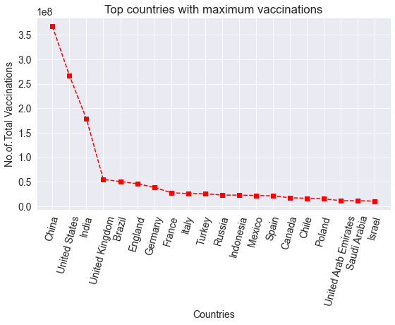

```python
plt.plot(top20_vacc,'s--r');
plt.xticks(rotation=75);
plt.title("Top countries with maximum vaccinations");
plt.xlabel('Countries');
plt.ylabel('No.of.Total Vaccinations');
```

```python
print("Number of various vaccanies given across the world are {}"
      .format(dataset_df.vaccines.nunique()))
```

```
Number of various vaccanies given across the world are 41
```

### Average number of people vaccinated

```python
print("Average number of people vaccinated across the world are {}" .format(dataset_df.people_vaccinated.mean()))
```

```
Average number of people vaccinated across the world are 3499999.948981734
```

### Distribution of Total Vaccinations per hundered

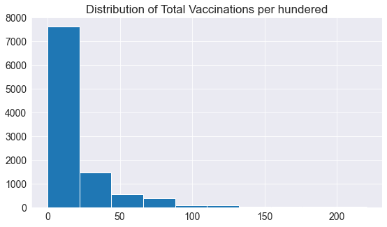

```python
plt.title('Distribution of Total Vaccinations per hundered')
plt.hist(dataset_df.total_vaccinations_per_hundred);
```

### Count of various vaccinations in the dataset

```python
dataset_df['vaccines'].value_counts()
```

```
Oxford/AstraZeneca                                                                    3146
Moderna, Oxford/AstraZeneca, Pfizer/BioNTech                                          2265
Johnson&Johnson, Moderna, Oxford/AstraZeneca, Pfizer/BioNTech                         1896
Oxford/AstraZeneca, Pfizer/BioNTech                                                   1412
Pfizer/BioNTech                                                                       1184
Oxford/AstraZeneca, Pfizer/BioNTech, Sinovac                                           892
Moderna, Pfizer/BioNTech                                                               799
Oxford/AstraZeneca, Pfizer/BioNTech, Sinopharm/Beijing, Sputnik V                      775
Oxford/AstraZeneca, Sinopharm/Beijing                                                  667
Sputnik V                                                                              499
Oxford/AstraZeneca, Sinovac                                                            316
Sinopharm/Beijing                                                                      292
Oxford/AstraZeneca, Pfizer/BioNTech, Sinopharm/Beijing                                 271
Pfizer/BioNTech, Sinopharm/Beijing                                                     208
Pfizer/BioNTech, Sinovac                                                               202
Oxford/AstraZeneca, Pfizer/BioNTech, Sinovac, Sputnik V                                199
Oxford/AstraZeneca, Sinopharm/Beijing, Sinovac                                         197
Sinopharm/Beijing, Sinopharm/Wuhan, Sinovac                                            150
EpiVacCorona, Sputnik V                                                                150
Oxford/AstraZeneca, Sinopharm/Beijing, Sputnik V                                       148
Johnson&Johnson, Moderna, Pfizer/BioNTech                                              145
CanSino, Oxford/AstraZeneca, Pfizer/BioNTech, Sinovac, Sputnik V                       140
Oxford/AstraZeneca, Sputnik V                                                          139
Moderna, Oxford/AstraZeneca, Pfizer/BioNTech, Sinopharm/Beijing, Sputnik V             137
Covaxin, Oxford/AstraZeneca, Sinopharm/Beijing                                         130
Oxford/AstraZeneca, Pfizer/BioNTech, Sinopharm/Beijing, Sinopharm/Wuhan, Sputnik V     129
Johnson&Johnson, Oxford/AstraZeneca, Pfizer/BioNTech                                   127
Covaxin, Oxford/AstraZeneca                                                            120
Moderna, Oxford/AstraZeneca                                                            118
Oxford/AstraZeneca, Sinopharm/Beijing, Sinovac, Sputnik V                              108
Sinopharm/Beijing, Sputnik V                                                           103
CanSino, Sinopharm/Beijing, Sinovac, Sputnik V                                         101
Covaxin, Oxford/AstraZeneca, Sinopharm/Beijing, Sputnik V                               92
Johnson&Johnson                                                                         87
Pfizer/BioNTech, Sputnik V                                                              75
Oxford/AstraZeneca, Sinovac, Sputnik V                                                  73
Pfizer/BioNTech, Sinovac, Sputnik V                                                     60
Moderna, Oxford/AstraZeneca, Sinopharm/Beijing, Sputnik V                               29
Johnson&Johnson, Moderna, Oxford/AstraZeneca, Pfizer/BioNTech, Sputnik V                24
EpiVacCorona, Oxford/AstraZeneca, Sinopharm/Beijing, Sputnik V                           1
Abdala                                                                                   1
Name: vaccines, dtype: int64
```

```python
print("Total number of vaccinations in the dataset are: {}"
      .format(dataset_df['vaccines'].value_counts().sum()))
```

```
Total number of vaccinations in the dataset are: 17607
```

### Average number of vaccinations produced by manufactures

Here we extra the file called: `country_vaccinations_by_manufacturer.csv` from the working directory, which is originally downloaded from kaggle.

```python
vacc_dataset = pd.read_csv('country_vaccinations_by_manufacturer.csv')
```

```python
vacc_dataset.total_vaccinations.mean()
```

```
5168580.8177521005
```

```python
import jovian
```

```python
jovian.commit()
```

```
[jovian] Attempting to save notebook..
[jovian] Updating notebook "kiranprasanth01/covid-19-world-vacination-progress-analysis" on https://jovian.ai/
[jovian] Uploading notebook..
[jovian] Capturing environment..
[jovian] Committed successfully! https://jovian.ai/kiranprasanth01/covid-19-world-vacination-progress-analysis
```

```
'https://jovian.ai/kiranprasanth01/covid-19-world-vacination-progress-analysis'
```

## Step: 4 Asking and Answering Questions

Here we try asking and solving various questions that can leads us to draw some conclusions and inferences about the COVID-19 Vaccination progress dataset

### Q1: Which vaccine people had taken the most?

```python
tot_vacc = dataset_df.groupby('vaccines')[['total_vaccinations']].max()
```

```python
counts_vacc = tot_vacc.sort_values('total_vaccinations',ascending=False)
counts_vacc
```

| vaccines | total_vaccinations |
| --- | --- |
| Sinopharm/Beijing, Sinopharm/Wuhan, Sinovac | 366910000.0 |
| Johnson&Johnson, Moderna, Pfizer/BioNTech | 266596486.0 |
| Covaxin, Oxford/AstraZeneca | 178361846.0 |
| Moderna, Oxford/AstraZeneca, Pfizer/BioNTech | 54797640.0 |
| Oxford/AstraZeneca, Pfizer/BioNTech, Sinovac | 50308106.0 |
| Johnson&Johnson, Moderna, Oxford/AstraZeneca, Pfizer/BioNTech | 38646171.0 |
| Pfizer/BioNTech, Sinovac | 25402277.0 |
| EpiVacCorona, Sputnik V | 22782931.0 |
| Oxford/AstraZeneca, Sinovac | 22617205.0 |
| CanSino, Oxford/AstraZeneca, Pfizer/BioNTech, Sinovac, Sputnik V | 21986456.0 |
| Oxford/AstraZeneca, Pfizer/BioNTech, Sinopharm/Beijing, Sinopharm/Wuhan, Sputnik V | 11422565.0 |
| Oxford/AstraZeneca, Pfizer/BioNTech | 11195164.0 |
| Moderna, Pfizer/BioNTech | 10525163.0 |
| Oxford/AstraZeneca, Sinopharm/Beijing | 10436046.0 |
| Oxford/AstraZeneca, Sinopharm/Beijing, Sputnik V | 9541511.0 |
| Oxford/AstraZeneca | 9316086.0 |
| Moderna, Oxford/AstraZeneca, Pfizer/BioNTech, Sinopharm/Beijing, Sputnik V | 7110455.0 |
| Pfizer/BioNTech | 5593436.0 |
| Oxford/AstraZeneca, Pfizer/BioNTech, Sinopharm/Beijing, Sputnik V | 3915922.0 |
| CanSino, Sinopharm/Beijing, Sinovac, Sputnik V | 3836291.0 |
| Oxford/AstraZeneca, Sinopharm/Beijing, Sinovac | 3132686.0 |
| Oxford/AstraZeneca, Sinovac, Sputnik V | 2542066.0 |
| Sputnik V | 2455655.0 |
| Oxford/AstraZeneca, Pfizer/BioNTech, Sinopharm/Beijing | 2261096.0 |
| Covaxin, Oxford/AstraZeneca, Sinopharm/Beijing, Sputnik V | 1767570.0 |
| Oxford/AstraZeneca, Sinopharm/Beijing, Sinovac, Sputnik V | 1371976.0 |
| Pfizer/BioNTech, Sinopharm/Beijing | 1091048.0 |
| Oxford/AstraZeneca, Sputnik V | 930460.0 |
| Sinopharm/Beijing | 730365.0 |
| Oxford/AstraZeneca, Pfizer/BioNTech, Sinovac, Sputnik V | 632676.0 |
| Sinopharm/Beijing, Sputnik V | 563466.0 |
| Pfizer/BioNTech, Sinovac, Sputnik V | 537380.0 |
| Johnson&Johnson | 455169.0 |
| Johnson&Johnson, Oxford/AstraZeneca, Pfizer/BioNTech | 400004.0 |
| Moderna, Oxford/AstraZeneca | 245772.0 |
| Covaxin, Oxford/AstraZeneca, Sinopharm/Beijing | 220646.0 |
| Johnson&Johnson, Moderna, Oxford/AstraZeneca, Pfizer/BioNTech, Sputnik V | 106559.0 |
| Abdala | 70000.0 |
| EpiVacCorona, Oxford/AstraZeneca, Sinopharm/Beijing, Sputnik V | 41993.0 |
| Moderna, Oxford/AstraZeneca, Sinopharm/Beijing, Sputnik V | 38151.0 |
| Pfizer/BioNTech, Sputnik V | 36735.0 |

From the observation above, People had taken `Sinopharm` Vaccine the most across the world, when compared to other vaccines present

### Q2:What are the Countries who have Sinopharm vaccines?

```python
vacc_country = dataset_df.groupby('country')[['vaccines']].max()
```

```python
vacc_country[vacc_country.vaccines=='Sinopharm/Beijing']
```

| country | vaccines |
| --- | --- |
| Cameroon | Sinopharm/Beijing |
| Equatorial Guinea | Sinopharm/Beijing |
| Gabon | Sinopharm/Beijing |
| Mauritania | Sinopharm/Beijing |
| Senegal | Sinopharm/Beijing |
| Zimbabwe | Sinopharm/Beijing |

These are six countries with Sinopharm/Beijing vaccines

### Q3: What are the Top 20 Countries with best daily average vacinations?

```python
a= dataset_df.groupby("country").daily_vaccinations.mean().sort_values(ascending= False).head(20)
```

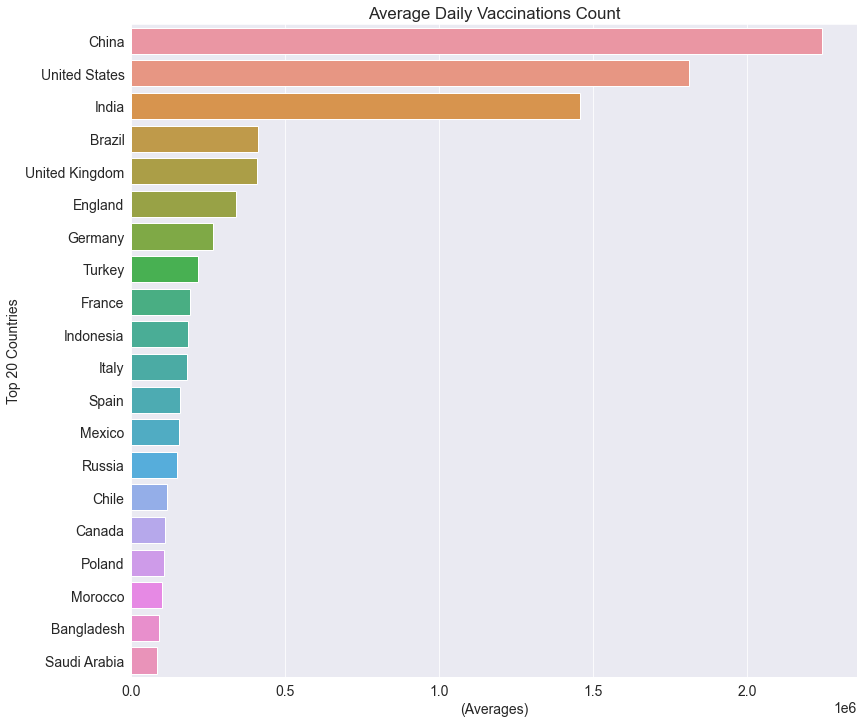

```python
plt.figure(figsize= (13,12));
sns.barplot(a.values,a.index);
plt.title("Average Daily Vaccinations Count");
plt.xlabel("(Averages)");
plt.ylabel("Top 20 Countries");
```

### Q4: What are the top Countries with fully vaccinated people?

```python
top_fully_vacc = dataset_df.groupby("country").people_fully_vaccinated.max().sort_values(ascending= False).head(20)
```

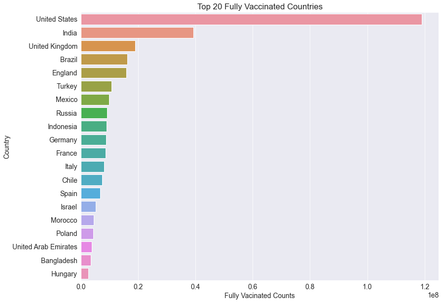

```python
plt.figure(figsize=(13,10))
sns.barplot(top_fully_vacc.values,top_fully_vacc.index);
plt.title('Top 20 Fully Vaccinated Countries');
plt.xlabel('Fully Vacinated Counts');
plt.ylabel('Country');
```

### Q5: Top countries those got vaccinated the most?

```python
top_vacci = dataset_df.groupby("country")['total_vaccinations'].max().sort_values(ascending= False).head(5)
top_vacci
```

```
country
China             366910000.0
United States     266596486.0
India             178361846.0
United Kingdom     54797640.0
Brazil             50308106.0
Name: total_vaccinations, dtype: float64
```

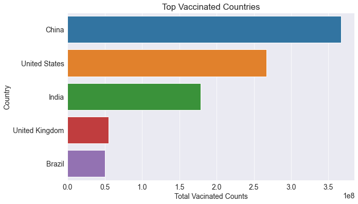

```python
plt.figure(figsize=(10,6))
sns.barplot(top_vacci.values,top_vacci.index);
plt.title('Top Vaccinated Countries');
plt.xlabel('Total Vacinated Counts');
plt.ylabel('Country');
```

Let us save and upload our work to Jovian before continuing.

```python
import jovian
```

```python
jovian.commit()
```

```
[jovian] Attempting to save notebook..
[jovian] Updating notebook "kiranprasanth01/covid-19-world-vacination-progress-analysis" on https://jovian.ai/
[jovian] Uploading notebook..
[jovian] Capturing environment..
[jovian] Committed successfully! https://jovian.ai/kiranprasanth01/covid-19-world-vacination-progress-analysis
```

```
'https://jovian.ai/kiranprasanth01/covid-19-world-vacination-progress-analysis'
```

## Inferences and Conclusion

### We reached the end!

```python
import jovian
```

```python
jovian.commit()
```

```
[jovian] Attempting to save notebook..
[jovian] Updating notebook "kiranprasanth01/covid-19-world-vacination-progress-analysis" on https://jovian.ai/
[jovian] Uploading notebook..
[jovian] Capturing environment..
[jovian] Committed successfully! https://jovian.ai/kiranprasanth01/covid-19-world-vacination-progress-analysis
```

```
'https://jovian.ai/kiranprasanth01/covid-19-world-vacination-progress-analysis'
```

## References and Future Work

### Ideas for Future Projects using this dataset

Some of the other intersting facts people can work on this dataset includes;

1. analysisng the trend of number of vaccinations to occurr in next 7 days or a month
2. Can perfrom Regression analysis to predict a particular countries vaccination progress

Try exploring the dataset: https://www.kaggle.com/gpreda/covid-world-vaccination-progress

[figure not shown]

```python
import jovian
```

```python
jovian.commit()
```

```
[jovian] Attempting to save notebook..
[jovian] Updating notebook "kiranprasanth01/covid-19-world-vacination-progress-analysis" on https://jovian.ai/
[jovian] Uploading notebook..
[jovian] Capturing environment..
[jovian] Committed successfully! https://jovian.ai/kiranprasanth01/covid-19-world-vacination-progress-analysis
```

```
'https://jovian.ai/kiranprasanth01/covid-19-world-vacination-progress-analysis'
```

```python
jovian.submit(assignment="zero-to-pandas-project")
```

```
[jovian] Attempting to save notebook..
[jovian] Updating notebook "kiranprasanth01/covid-19-world-vacination-progress-analysis" on https://jovian.ai/
[jovian] Uploading notebook..
[jovian] Capturing environment..
[jovian] Committed successfully! https://jovian.ai/kiranprasanth01/covid-19-world-vacination-progress-analysis
[jovian] Submitting assignment..
[jovian] Verify your submission at https://jovian.ai/learn/data-analysis-with-python-zero-to-pandas/assignment/course-project
```